# Project Python Foundations: FoodHub Data Analysis

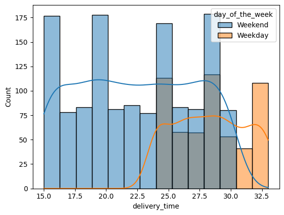

```python
sns.histplot(data=df, x='delivery_time', hue='day_of_the_week', kde=True)
```

rating vs cost

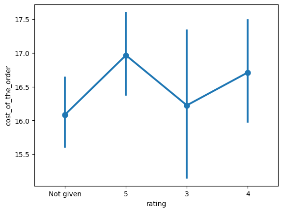

```python
sns.pointplot(data=df, x='rating', y='cost_of_the_order')
```

even without dealing with the outliers there is still a relationship here... the cost seems to be positively corrolated to the rating showing that people dont neccessarily mind paying a bit extra for better food with all else being equal. if we adress problems like delivery time, promote new cuisines of food, and subtly change the way we calculate our margins we should see a revenue increase

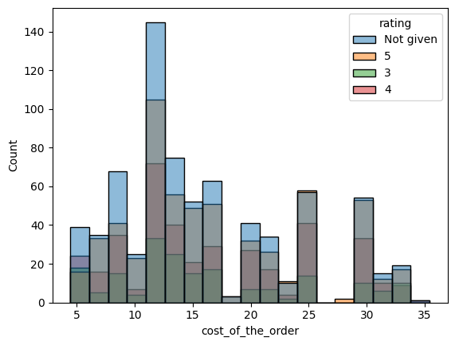

```python
sns.histplot(data=df, hue='rating', x='cost_of_the_order')
```

maybe if i changed the color scheme this would be easier to look at but i feel like we already got enough... moving on.

cuisine vs food preparation time

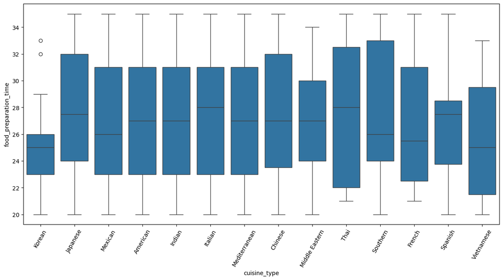

```python
plt.figure(figsize=(15, 7))
sns.boxplot(x='cuisine_type', y='food_preparation_time', data=df)
plt.xticks(rotation=60)
plt.show()
```

all cuisine types prepare the food in a similar amount of time. but some of the cuisine types that we were interested in do have slightly higher prep times so we will have to be careful when we pick specific restaurants in these cuisine types.

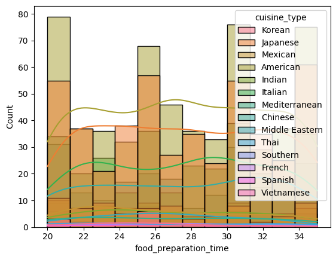

```python
sns.histplot(data=df, x='food_preparation_time', hue='cuisine_type', kde=True)
```

rating vs delivery time

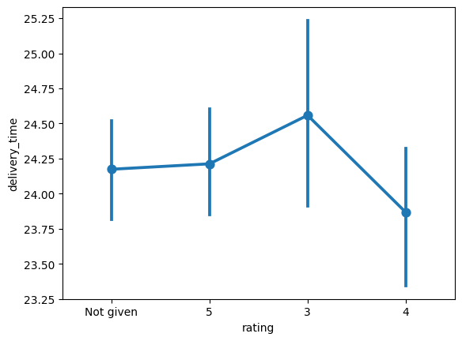

```python
sns.pointplot(x = 'rating', y = 'delivery_time', data = df)
plt.show()
```

it seems like food quality is more important than delivery time for the rating since it goes down to the seconds not minutes. it would be nice to know what the not givens mean here but its not that important

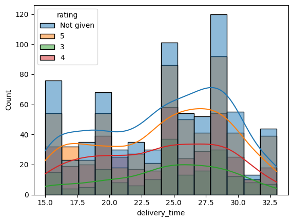

```python
sns.histplot(data=df, x='delivery_time', hue='rating', kde=True)
```

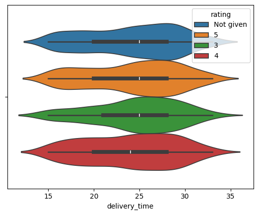

```python
sns.violinplot(data=df, x='delivery_time', hue='rating')
```

not that important which means we are free to focus on quality and type and drill down as far as specific restaurants for our analysis as long as preparation time doesnt imact the rating in any meaningful way

rating vs food preparation time

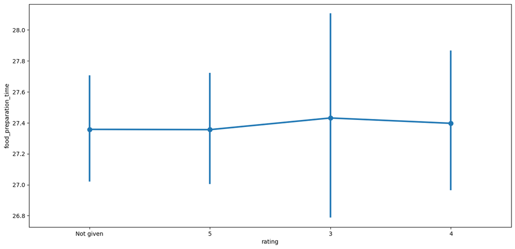

```python
plt.figure(figsize=(15, 7))
sns.pointplot(data=df, x='rating', y='food_preparation_time')
plt.show()
```

doesnt seem to matter all that much either so we should definatly try exposing people to new resturanuts and cuisine types. imputation wont really lield anything insightful for our time variables most likely but its still something we should keep in mind for our other column variables

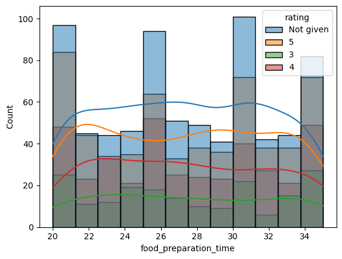

```python
sns.histplot(data=df, x='food_preparation_time', hue='rating', kde=True)
```

day of the week vs cuisine type vs rating

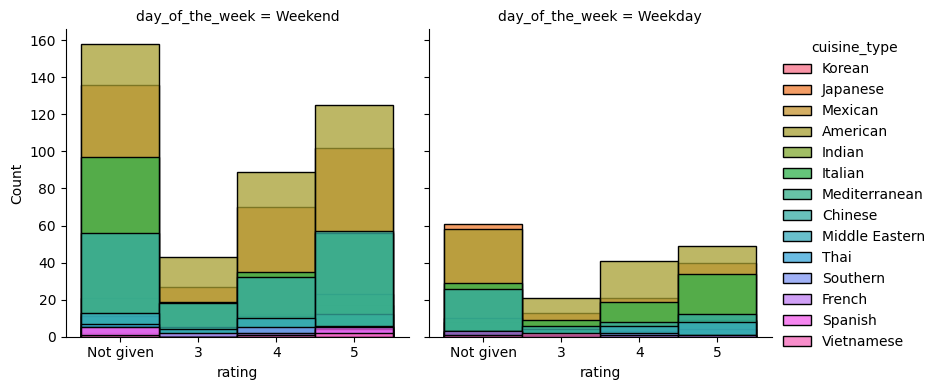

```python
g = sns.FacetGrid(df, col="day_of_the_week", hue="cuisine_type", height=4, aspect=1)
g.map(sns.histplot, "rating")
g.add_legend()
plt.show()
```

a lot changes between weekends and weekdays when you break it down like this some of our higher margin cuisine types we are intersted in get a similar spread of ratings as other cuisine types but with much less frequency we need to find out how to increase that frequency although their performance on weekdays seems strange.

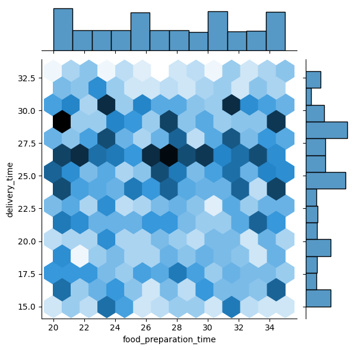

```python
sns.jointplot(data=df,x='food_preparation_time',y='delivery_time', kind='hex')
```

this means little but its nice to look at

cuisine and cost

this doesnt show corrolation but it is useful for clustering

[figure not shown]

```python
#another way of showing this relationship
g=sns.FacetGrid(df,col='cuisine_type')
g.map(sns.histplot,'cost_of_the_order')
```

it would definatly be a good idea to run cultural promos on certain holidays to try and get people hooked on new cuisine types that have better margins. for instance people who enjoy american food should get promo codes for southern food, people who like chinese and japanese should get promos for thai and indian. and people who like italian should get promos for french on bastille day or something.